# Kickstarter state from 2009 to 2018

Siwei WANG

20/04/2019

[figure not shown]

## I. Data Source

#### First of all, Kaggle.com provides the data. Here is [the link](https://www.kaggle.com/kemical/kickstarter-projects) of the original page.

## II. Introduction

“Kickstarter is an enormous global community built around creativity and creative projects. Over 10 million people, from every continent on earth, have backed a Kickstarter project. Some of those projects come from influential artists like De La Soul or Marina Abramović. Most come from amazing creative people you probably haven’t heard of — from Grandma Pearl to indie filmmakers to the band down the street. Every artist, filmmaker, designer, developer, and creator on Kickstarter has complete creative control over their work — and the opportunity to share it with a vibrant community of backers.”

This is the brief self-introduction from Kickstarter official website. I got to know their website because of some independent video games which are made by individuals or small studios who were lack of funding and finally published their games after they had used Kickstarter to gain enough money. Since it became more and more popular, there are several questions I think people might be interested in:

1. How many projects exist on Kickstarter? What’s the main categories and the subcategories?
2. How many of them finally were successful?
3. How much money did they aim for? How much did they really get?
4. For raising the funding, how long did they take? (period)
5. How is the development of projects on Kickstarter in these years, did the amount increase or decrease?

## III. Libraries

```r
library(tidyverse)
library(ggthemes)
library(lubridate)
library(rworldmap)
library(gplots)
library(knitr)
library(data.table)
```

## IV. Questions

#### Before the analysis, here is the general statement of the whole data document:

```r
ksdata <- read.csv("ks-projects-201801.csv")
str(ksdata)
```

```
## 'data.frame':    378661 obs. of  15 variables:
##  $ ID              : int  1000002330 1000003930 1000004038 1000007540 1000011046 1000014025 1000023410 1000030581 1000034518 100004195 ...
##  $ name            : Factor w/ 375721 levels "","\177Not Twins - New EP! \"The View from Down Here\"",..: 332454 135608 364952 344727 77249 206047 293388 69257 284064 290643 ...
##  $ category        : Factor w/ 159 levels "3D Printing",..: 109 94 94 91 56 124 59 42 114 40 ...
##  $ main_category   : Factor w/ 15 levels "Art","Comics",..: 13 7 7 11 7 8 8 8 5 7 ...
##  $ currency        : Factor w/ 14 levels "AUD","CAD","CHF",..: 6 14 14 14 14 14 14 14 14 14 ...
##  $ deadline        : Factor w/ 3164 levels "2009/10/1","2009/10/10",..: 2068 2800 1418 1101 2332 2555 1747 2532 1875 1947 ...
##  $ goal            : num  1000 30000 45000 5000 19500 50000 1000 25000 125000 65000 ...
##  $ launched        : Factor w/ 347035 levels "1970/1/1 1:00",..: 235831 344679 75696 52438 234335 265592 131837 262573 145574 157286 ...
##  $ pledged         : num  0 2421 220 1 1283 ...
##  $ state           : Factor w/ 6 levels "canceled","failed",..: 2 2 2 2 1 4 4 2 1 1 ...
##  $ backers         : int  0 15 3 1 14 224 16 40 58 43 ...
##  $ country         : Factor w/ 23 levels "AT","AU","BE",..: 10 23 23 23 23 23 23 23 23 23 ...
##  $ usd.pledged     : num  0 100 220 1 1283 ...
##  $ usd_pledged_real: num  0 2421 220 1 1283 ...
##  $ usd_goal_real   : num  1534 30000 45000 5000 19500 ...
```

As you can see, this is a data frame with 378661 rows and 15 columns, including the names of projects, categories, sub-categories, pledged money, etc.

```r
sapply(ksdata, function(x) sum(is.na(x)))
```

```
##               ID             name         category    main_category
##                0                0                0                0
##         currency         deadline             goal         launched
##                0                0                0                0
##          pledged            state          backers          country
##                0                0                0                0
##      usd.pledged usd_pledged_real    usd_goal_real
##             3797                0                0
```

NA value only exist in column “usd.pledged”. However, this column is not useful since there is already another column called “usd_pleged_real”, which contains the information about pledged money we need.

```r
ksdata <- ksdata[,-13]
colnames(ksdata)[13] <- "pledged_usd"
colnames(ksdata)[14] <- "goal_usd"
```

Let’s start with the first question.

### 1. How many projects exist on Kickstarter? What’s the main categories and the subcategories?

In the data, from 2009 to 2018.01, there is 378661 projects recorded.

We can use ggplot package to show the chart of summary of the categories of projects.

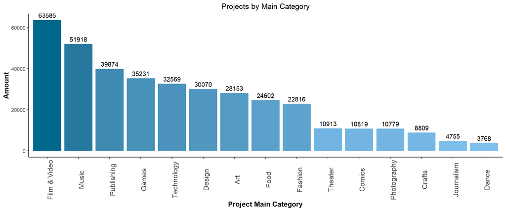

```r
catesum <- ksdata %>%
group_by(main_category) %>%
summarize(count=n()) %>%
arrange(desc(count))
catesum$main_category <- factor(catesum$main_category, levels=catesum$main_category)

ggplot(catesum, aes(main_category, count, fill=count)) + geom_bar(stat="identity") + ggtitle("Projects by Main Category") + xlab("Project Main Category") + ylab("Amount") + geom_text(aes(label=count), vjust=-0.5) + theme_classic() + theme(plot.title=element_text(hjust=0.5), axis.title=element_text(size=12, face="bold"), axis.text.x=element_text(size=12, angle=90), legend.position="null") + scale_fill_gradient(low="skyblue2",high = "deepskyblue4")
```

*Film & Video* seems to be the most popular main category on Kickstarter. *Dance* is the least one.

Next is the subcategory. However, it contains too many subcategories, we only present the main 15 subcategories instead.

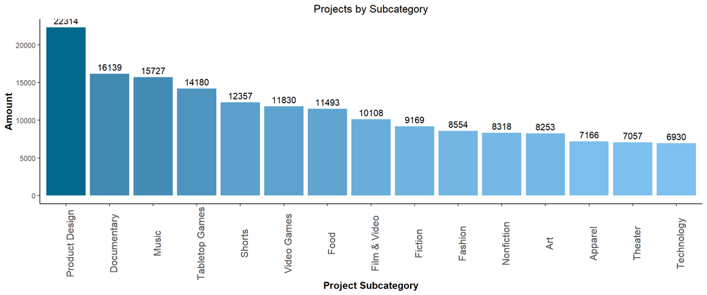

```r
subcate <- ksdata %>%
group_by(category) %>%
summarize(count=n()) %>%
arrange(desc(count))

subcate$category <- factor(subcate$category, levels=subcate$category)
ggplot(head(subcate, 15), aes(category, count, fill=count)) + geom_bar(stat="identity") + ggtitle("Projects by Subcategory") + xlab("Project Subcategory") + ylab("Amount") + geom_text(aes(label=count), vjust=-0.5) + theme_classic() + theme(plot.title=element_text(hjust=0.5), axis.title=element_text(size=12, face="bold"), axis.text.x=element_text(size=12, angle=90), legend.position="null") + scale_fill_gradient(low="skyblue2", high="deepskyblue4")
```

For subcategories, *Product Design* is the most popular subcategory here, stemming from the category of Design.

### 2. How many of them finally were successful?

```r
sucrate <- prop.table(table(ksdata$state))*100
sucrate
```

```
##
##   canceled     failed       live successful  suspended  undefined
## 10.2410864 52.2153060  0.7391836 35.3762336  0.4875073  0.9406831
```

Only around **35.38%** of projects were successful.

### 3. How much money did they aim for? How much did they get?

For these projects failed, let’s see how much money did they ask for.

```r
kable(head(ksdata[order(-ksdata$goal_usd), c(2,3,14,10)], 15))
```

|  | name | category | goal_usd | state |
| --- | --- | --- | --- | --- |
| 47804 | FUCK Potato Salad. Paleo Potato Brownies! | Food | 166361391 | failed |
| 196532 | A Celtic Lovestory | Drama | 151395870 | failed |
| 367929 | Hydroponic’s Skyscraper(un gratte-ciel hydroponique)e-solar | Technology | 110169772 | failed |
| 222209 | DER NEANDERTALER (Kinofilm mit Starbesetzung in 3D) | Movie Theaters | 107369868 | failed |
| 226162 | Kitchen from Austria in Switzerland | Restaurants | 104057190 | failed |
| 23470 | Help me start a fair media company, Trump Media | Video | 100000000 | failed |
| 33085 | Sage: Warrior Of The Fallen Gods (Movie) | Fantasy | 100000000 | failed |
| 55010 | Kybernan Holographic Gaming Network | Video Games | 100000000 | failed |
| 72776 | Art Is Fabulous | Art | 100000000 | failed |
| 72991 | Wax Apple | Documentary | 100000000 | failed |
| 77677 | Bring back Pontiac | Technology | 100000000 | failed |
| 145944 | Let’s prove the earth is FLAT! (Suspended) (Suspended) | Video | 100000000 | suspended |
| 158460 | The Return Of The Bell Witch Movie | Shorts | 100000000 | failed |
| 160292 | The Book on Comedy 10 GABAGILLTRILLBILLIOPLEXIAN!!!!!!!!!!!! | Comics | 100000000 | failed |
| 211027 | Virtual Reality Playground in Buffalo, NY | Live Games | 100000000 | failed |

It is obvious that lots of projects with exaggerating money requirement (more than 10,000,000 usd) failed in the end. But how about the successful projects, what’s the highest price they required for?

```r
goaltops <- ksdata[ksdata$state=="successful",]
kable(head(goaltops[order(-goaltops$goal_usd), c(2,3,14,10)], 15))
```

|  | name | category | goal_usd | state |
| --- | --- | --- | --- | --- |
| 355331 | Elite: Dangerous | Video Games | 2015609 | successful |
| 89482 | Bring Back MYSTERY SCIENCE THEATER 3000 | Television | 2000000 | successful |
| 134463 | Camelot Unchained | Video Games | 2000000 | successful |
| 148586 | The Veronica Mars Movie Project | Narrative Film | 2000000 | successful |
| 171323 | WISH I WAS HERE | Narrative Film | 2000000 | successful |
| 368574 | Shenmue 3 | Video Games | 2000000 | successful |
| 324292 | Blue Mountain State: The Movie | Narrative Film | 1500000 | successful |
| 111637 | The Newest Hottest Spike Lee Joint | Narrative Film | 1250000 | successful |
| 337373 | The Bards Tale IV | Video Games | 1250000 | successful |
| 141639 | Obduction | Video Games | 1100000 | successful |
| 272925 | Project Eternity | Video Games | 1100000 | successful |
| 30719 | Shroud of the Avatar: Forsaken Virtues | Video Games | 1000000 | successful |
| 37515 | Pathfinder Online: A Fantasy Sandbox MMO | Video Games | 1000000 | successful |
| 189800 | ARKYD: A Space Telescope for Everyone | Space Exploration | 1000000 | successful |
| 216630 | Pebble 2, Time 2 + All-New Pebble Core | Product Design | 1000000 | successful |

Even the highest one, Elite: Dangerous is just 2,015,609 usd. Most of them is around 2,000,000 usd. Also, in this list, video games is the category most of which got highest funded. (Though this is the goal of project, but for those projects succeed, goals should be equal to or even less than how much they actually got funded.)

How about the general state of real pledged amount of each main categories?

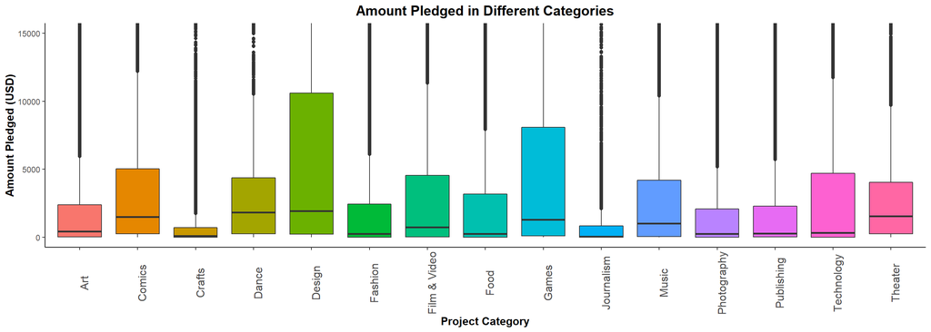

```r
p <- ggplot(ksdata, aes(main_category, pledged_usd, fill=main_category))
p + geom_boxplot() + theme_classic() +
ggtitle("Amount Pledged in Different Categories") +
xlab("Project Category") +
ylab("Amount Pledged (USD)") +
theme(plot.title=element_text(size=15, face="bold", hjust=0.5), axis.title=element_text(size=12, face="bold"), axis.text.x=element_text(size=12, angle=90), legend.position="null") + coord_cartesian(ylim=c(0,15000))
```

This time it is a little different. Actually we can see that *Design* instead of Film & Video, which contains most projects on Kickstarter, raised most money compared to any other categories. Then it’s *Games*, in which projects have highest pledged goals and also have high rate to succeed.

### 4. For raising the funding, how long did they take? (period)

Sorry this part I need more time to figure it out so I didn’t finish it. Skip to next part.

### 5. How is the development of projects on Kickstarter in these years, did the amount increase or decrease?

```r
ksdata$launch_year <- substr(ksdata$launched, 1,4)
table(ksdata$launch_year)
```

```
##
##  1970  2009  2010  2011  2012  2013  2014  2015  2016  2017  2018
##     7  1329 10519 26237 41165 44851 67745 77300 57184 52200   124
```

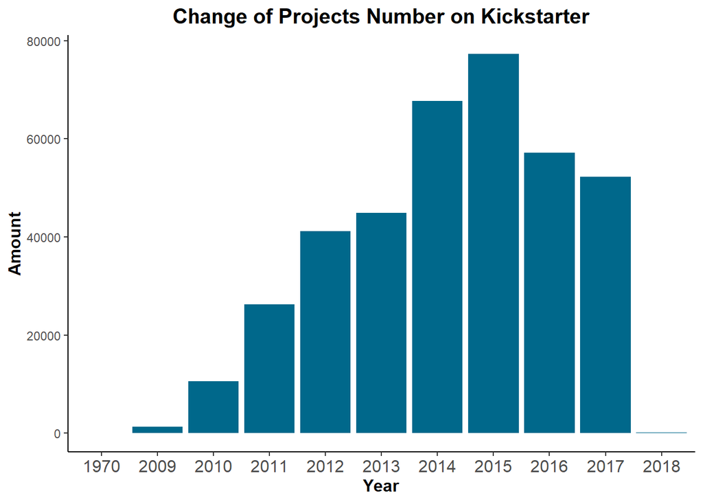

```r
ggplot(ksdata,aes(ksdata$launch_year)) +
geom_bar(fill="deepskyblue4") +
theme_classic() +
xlab("Year")+
ylab("Amount")+
ggtitle("Change of Projects Number on Kickstarter") +
theme(plot.title=element_text(size=15,face="bold", hjust=0.5), axis.title=element_text(size=12, face="bold"), axis.text.x=element_text(size=12, angle=0), legend.position="null")
```

From the tendency, it seems that the number of projects on Kickstarter increased untill 2015, then it went down and kept a balance around 50,000.

## VI. Conclusion

Kickstarter is still a good choice for anyone who wants to raise money for his or her creative ideas. But if you plan to use it, remember to consider your requirement carefully.

Thank you for reading!

[figure not shown]